# Tarea_2

Alvaro Polo García

19/9/2021

# TAREA 2

## Ejercicio1. Simulando variables aleatorias discretas.

### *Apartado 1*

```r
X1 = c(0:3)
P1 = c(64/125, 48/125, 12/125, 1/125)

mu_1 = sum(X1*P1)
sigma2_1= sum((X1 - mu_1)^2*P1)

mu_1
```

```
## [1] 0.6
```

```r
sigma2_1
```

```
## [1] 0.48
```

### *Apartado 2*

Combina sample con replicate para simular cien mil muestras de tamaño 10 de esta variable X1. Estudia la distribución de las medias muestrales como hemos hecho en ejemplos previos, ilustrando con gráficas la distribución de esas medias muestrales.

```r
set.seed(1)
k = 100000

X1 = c(0:3)
P1 = c(64/125, 48/125, 12/125, 1/125)

mediasmuestrales = replicate(k, {
  muestra = sample(X1, size = 10, replace= TRUE, prob = P1)
  mean(muestra)
})

head(mediasmuestrales,20)
```

```
##  [1] 0.9 0.6 0.4 0.5 0.8 0.3 0.5 0.6 0.3 0.6 0.8 0.5 0.4 0.9 0.5 0.3 0.4 0.9 0.7
## [20] 0.6
```

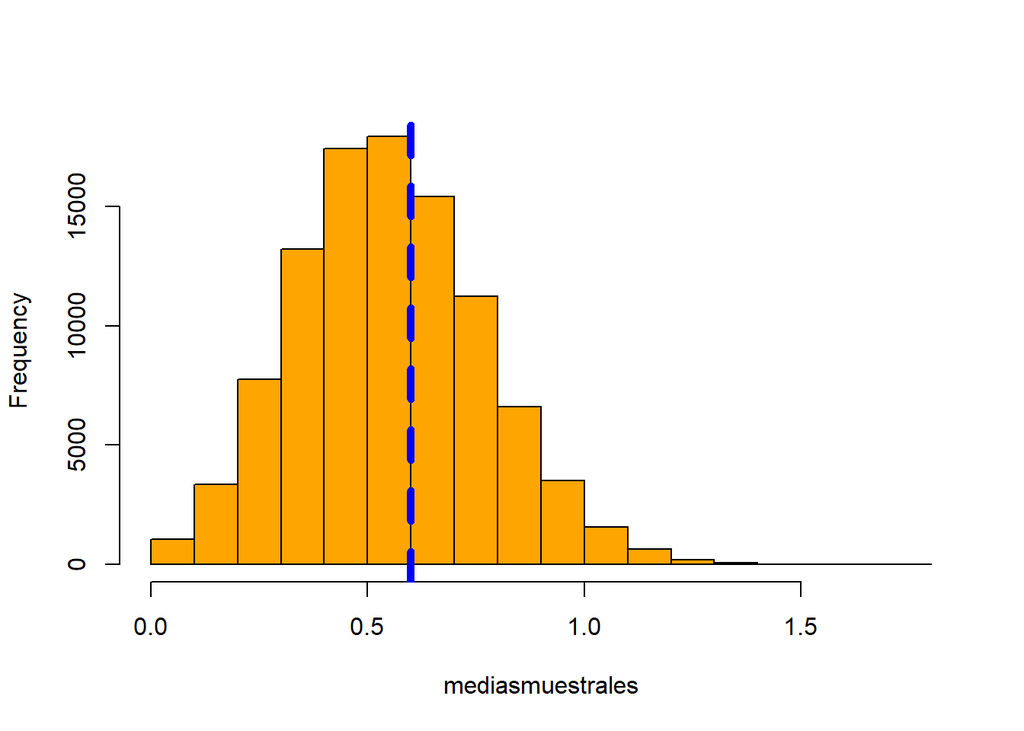

```r
hist(mediasmuestrales, main = "", col="orange")
abline(v = mean(mediasmuestrales), lty=2, lwd=5, col="blue")
```

Cambia después el tamaño de la muestra a 30 y repite el análisis.

```r
set.seed(1)
k = 100000

X1 = c(0:3)
P1 = c(64/125, 48/125, 12/125, 1/125)

mediasmuestrales = replicate(k, {
  muestra = sample(X1, size = 30, replace= TRUE, prob = P1)
  mean(muestra)
})

head(mediasmuestrales, 20)
```

```
##  [1] 0.6333333 0.5333333 0.4666667 0.6333333 0.6000000 0.5333333 0.5666667
##  [8] 0.6000000 0.5333333 0.2666667 0.6333333 0.5333333 0.5666667 0.7333333
## [15] 0.5333333 0.5333333 0.6333333 0.6333333 0.7666667 0.6000000
```

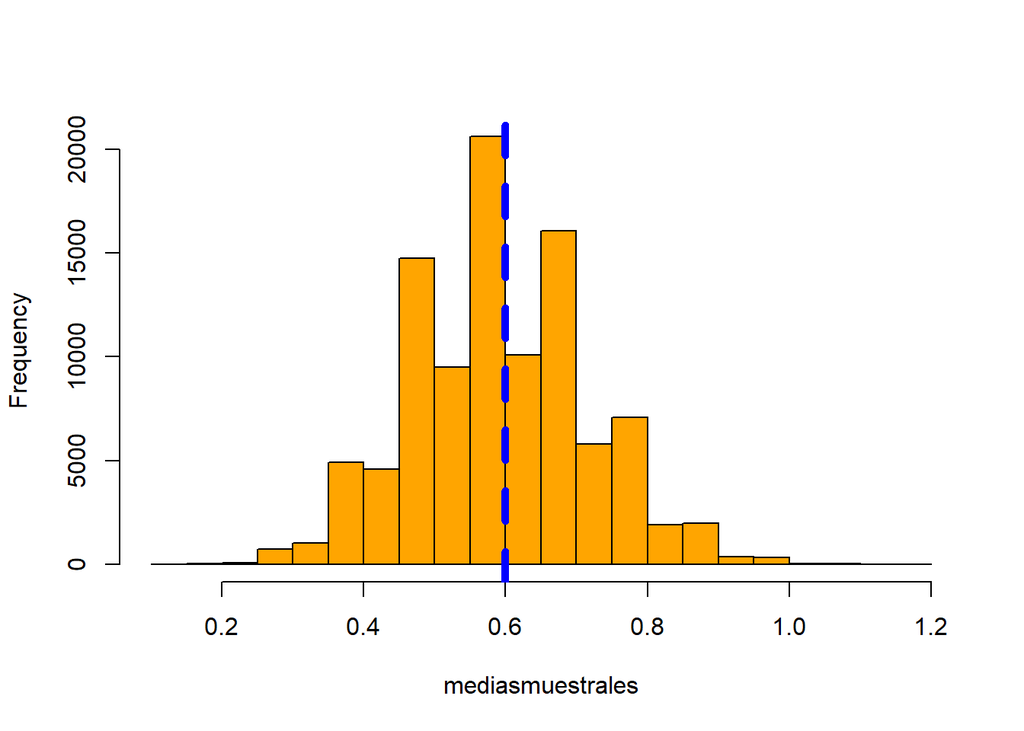

```r
hist(mediasmuestrales, main = "", col="orange")
abline(v = mean(mediasmuestrales), lty=2, lwd=5, col="blue")
```

### *Apartado 3*

Suponemos que X1 y X2 son independientes. ¿Qué valores puede tomar la suma X1 + X2?

- 6 posibles valores: 0,1,2,3,4,5

¿Cuál es su tabla de probabilidad?

```r
library(dplyr)
```

```r
p = c(64/125,48/125,12/125,1/125)*rep(c(1/2,1/4,1/4), each = 4)

X1 = rep(0:3,3)
X2 = rep(0:2, each = 4)
Z = X1+X2
table = data.frame(Z , X1, X2, p)


table2 = table %>%
  group_by(Z) %>%
  summarise(p = sum(p))

table2
```

```
## # A tibble: 6 x 2
##       Z     p
##   <int> <dbl>
## 1     0 0.256
## 2     1 0.32
## 3     2 0.272
## 4     3 0.124
## 5     4 0.026
## 6     5 0.002
```

### *Apartado 4*

Calcula la media teórica de la suma X1 + X2.

```r
X1 = c(0:3)
P1 = c(64/125, 48/125, 12/125, 1/125)
X2 = c(0:2)
P2 = c(1/2,1/4,1/4)

mu_2 = sum(X2*P2)

media_sum = mu_1 + mu_2

media_sum
```

```
## [1] 1.35
```

Después usa sample y replicate para simular cien mil valores de esta variable suma. Calcula la media de esos valores. Advertencia: no es el mismo tipo de análisis que hemos hecho en el segundo apartado.

```r
set.seed(1)
k = 100000

X1 = c(0:3)
P1 = c(64/125, 48/125, 12/125, 1/125)

X2 = c(0:2)
P2 = c(1/2,1/4,1/4)

medias_suma = replicate(k, {
  muestra = sample(0:3, size = 1, replace= TRUE, prob = c(64/125, 48/125, 12/125, 1/125)) + sample(0:2, size = 1, replace = TRUE,prob = c(1/2, 1/4, 1/4))
  mean(muestra)
})
mean(medias_suma)
```

```
## [1] 1.3518
```

## Ejercicio2. Datos Limpios

```r
library(tidyverse)
testResults <- read_csv("./data/testResults.csv")
```

Este fichero contiene las notas de los alumnos de una clase, que hicieron dos tests cada semana durante cinco semanas. La tabla de datos no cumple los principios de tidy data que hemos visto en clase. Tu tarea en este ejercicio es explicar por qué no se cumplen…

- Un conjunto de datos se considera *limpio* si cumple estas tres condiciones:

  $1.$ Cada variable tiene su propia columna.  
  $2.$ Cada observación tiene su propia fila.  
  $3.$ Cada valor tiene su propia celda.

…obtener una tabla de datos limpios con la misma información usando tidyR.

1.Vamos a separar la variable gender_age en gender y age, para ello utilizaremos un separate.

```r
testResults %>%
  separate(col  =  gender_age, into =  c("gender", "age"), sep  =  "_", convert = TRUE)
```

```
## # A tibble: 200 x 10
##    name           id gender   age test_number week1 week2 week3 week4 week5
##    <chr>       <dbl> <chr>  <int>       <dbl> <dbl> <dbl> <dbl> <dbl> <dbl>
##  1 Jacob         108 m         20           1     8     5     7     5     6
##  2 Jacob         108 m         20           2     2     2     4     0     3
##  3 Michael       490 m         19           1    10     0     5     4     0
##  4 Michael       490 m         19           2     9    10     8    10     9
##  5 Matthew       424 m         18           1     6     0     0     1    10
##  6 Matthew       424 m         18           2     3     4     2     5     8
##  7 Joshua        734 m         17           1    10     2     2     0     6
##  8 Joshua        734 m         17           2    10     0     6     8     9
##  9 Christopher   928 m         20           1     5     2     0     0     0
## 10 Christopher   928 m         20           2     9     9     3    10     4
## # ... with 190 more rows
```

2.Poner la semana en una única variable.

```r
testResults %>%
  separate(col  =  gender_age, into =  c("gender", "age"), sep  =  "_", convert = TRUE) %>%
  pivot_longer(week1:week5, names_to = "week", values_to = "grades")
```

```
## # A tibble: 1,000 x 7
##    name     id gender   age test_number week  grades
##    <chr> <dbl> <chr>  <int>       <dbl> <chr>  <dbl>
##  1 Jacob   108 m         20           1 week1      8
##  2 Jacob   108 m         20           1 week2      5
##  3 Jacob   108 m         20           1 week3      7
##  4 Jacob   108 m         20           1 week4      5
##  5 Jacob   108 m         20           1 week5      6
##  6 Jacob   108 m         20           2 week1      2
##  7 Jacob   108 m         20           2 week2      2
##  8 Jacob   108 m         20           2 week3      4
##  9 Jacob   108 m         20           2 week4      0
## 10 Jacob   108 m         20           2 week5      3
## # ... with 990 more rows
```

3.Borramos la palabra week de las semanas, para dejarlo con números enteros.

```r
testResults_limpios <- testResults %>%
  separate(col  =  gender_age, into =  c("gender", "age"), sep  =  "_", convert = TRUE) %>%
  pivot_longer(week1:week5, names_to = "week", values_to = "grades") %>%
  separate(col = week, into = c("week_delete", "week"), sep = 4, convert = TRUE) %>%
  select(-week_delete)

testResults_limpios
```

```
## # A tibble: 1,000 x 7
##    name     id gender   age test_number  week grades
##    <chr> <dbl> <chr>  <int>       <dbl> <int>  <dbl>
##  1 Jacob   108 m         20           1     1      8
##  2 Jacob   108 m         20           1     2      5
##  3 Jacob   108 m         20           1     3      7
##  4 Jacob   108 m         20           1     4      5
##  5 Jacob   108 m         20           1     5      6
##  6 Jacob   108 m         20           2     1      2
##  7 Jacob   108 m         20           2     2      2
##  8 Jacob   108 m         20           2     3      4
##  9 Jacob   108 m         20           2     4      0
## 10 Jacob   108 m         20           2     5      3
## # ... with 990 more rows
```